# Monte Carlo Simulation of CIED Longevity

STAT 400: Computational Statistics — Colorado State University

Group 4: Sydney, James, Waddah

# Motivation

- CIED (pacemaker) batteries require surgical replacement.
- Longevity prediction helps avoid too-early or too-late replacement.
- Lead impedance affects pacing current → may affect battery life.
- We use a Monte Carlo simulation to test whether impedance variability changes predicted longevity.

# Simulation Inputs

- 100,000 simulated patients.
- Variables included: heart rate, pacing %, battery capacity, background current, impedance.
- Two impedance conditions:
  - **Base:** fixed at 500 Ohms
  - **Extended:** N(500 Ohms, SD = 100 Ohms)
- Purpose: isolate the effect of impedance variability.

# Problem Statement & Methodology

- **Question:** Does impedance variability meaningfully change predicted longevity?
- **Steps:**
  1. Implement PCI model.
  2. Simulate patient and device parameters.
  3. Compute longevity under both impedance scenarios.
  4. Compare means and distributions.

# PCI Model: Concept Overview

- PCI = electrical load relative to battery capacity.
- Lower impedance → more current → shorter longevity.
- Components:
  - Pacing current
  - Background/system current
  - Optional features current

# PCI Model: Pacing Current Formula

```r
p_current <- function(v, pw_ms, r_ohm, hr = 60,
                      pace_fraction = 0.3){
  pw_sec  <- pw_ms / 1000
  i_pulse <- v / r_ohm
  q       <- i_pulse * pw_sec
  q_micro <- q * 1e6
  (q_micro * hr * pace_fraction) / 60
}
```

# PCI Model: Longevity Formula

```r
long <- function(i_background, i_pacing,
                 i_options, c_mah){
  c_uah      <- c_mah * 1000
  i_total    <- i_background + i_pacing +
    i_options
  PCI        <- i_total / c_uah
  long_hours <- 1 / PCI
  long_hours / 8760
}
```

# Monte Carlo Framework (How We Tested)

**For each of 100,000 patients:**

1. Calculate longevity with perfect 500 Ohms impedance
2. Calculate longevity with realistic variable impedance
3. Compare the two results

**This isolates** the effect of impedance variability by controlling for other patient differences

# Longevity Summary Table

| Scenario | Mean | Median | SD | Q1 | Q3 | n |
| --- | --- | --- | --- | --- | --- | --- |
| Base (500 Ohms) | 15.33 | 15.12 | 2.31 | 13.68 | 16.76 | 100,000 |
| Extended (±100 Ohms) | 15.26 | 15.08 | 2.37 | 13.58 | 16.73 | 100,000 |

- Longevity slightly lower under impedance variability.
- Differences are small.

# T-Test Results

```
Welch Two Sample t-test

t = 6.61
p-value = 3.76e-11

95% CI: 0.049 to 0.090 years
Mean(Base)     = 15.33
Mean(Extended) = 15.26
```

# Longevity Distribution Plot

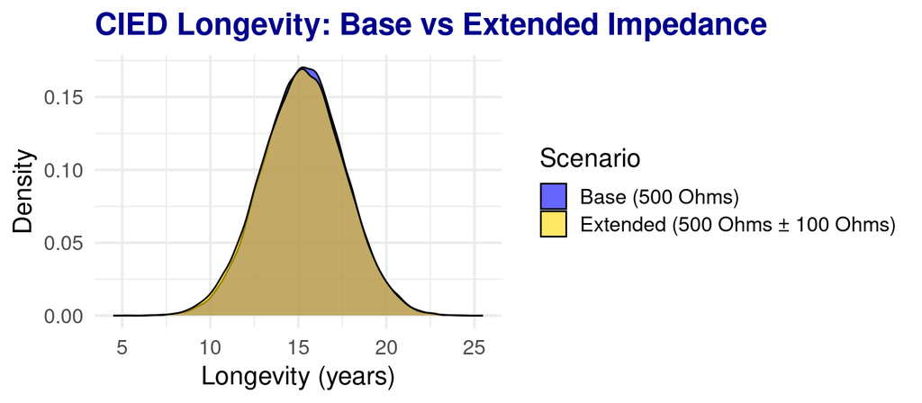

- Strong overlap → impedance variability has small effect.
- Near-identical distributions → minimal practical difference.
- Slight separation aligns with statistical findings.
- Same distribution shape → consistent prediction patterns.

# Discussion

- Background/system current has strongest influence on longevity.
- Impedance variability causes small, predictable changes.
- Pacing burden + background current dominate longevity outcomes.

# Limitations & Future Work

- Impedance treated as static (real devices drift).
- Model excludes multi-lead systems and adaptive algorithms.
- Could expand with dynamic impedance or clinical validation.

# Conclusion

- Impedance variability slightly reduces longevity.
- Predictions remain stable across realistic impedance ranges.
- Monte Carlo simulation provides strong framework for CIED evaluation.

# Thank You

**Questions?**